# Week 4 Natural Language Processing

### View Hashtags and mentions

Hashtags and mentions are important in tweets since they are used to enhance discoverability and facilitate conversation/participation. For disaster related tweets, if a group of tweets all have the same hashtag then it becomes more popular and focused globally. We would expect this phenomena to happen during disaster tweets where a group of tweets contribute to the news. On the other hand, we would expect more randomized hashtags/mentions for non-disaster tweets.

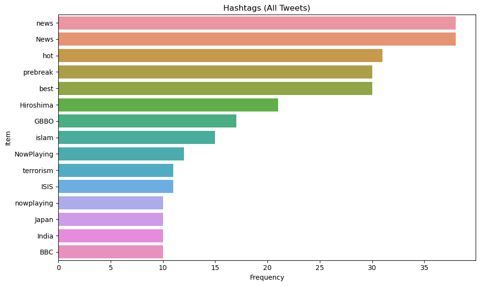

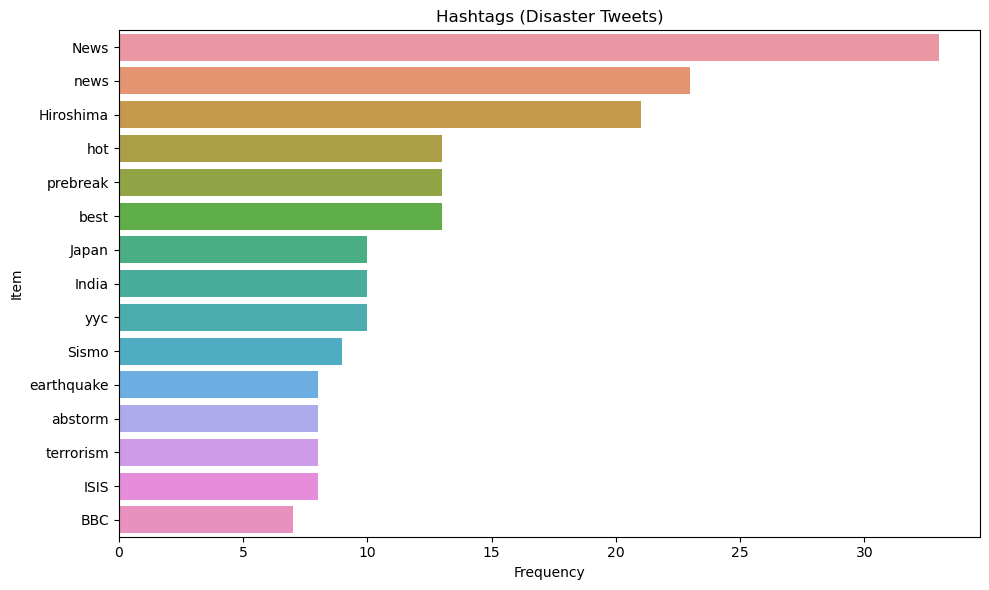

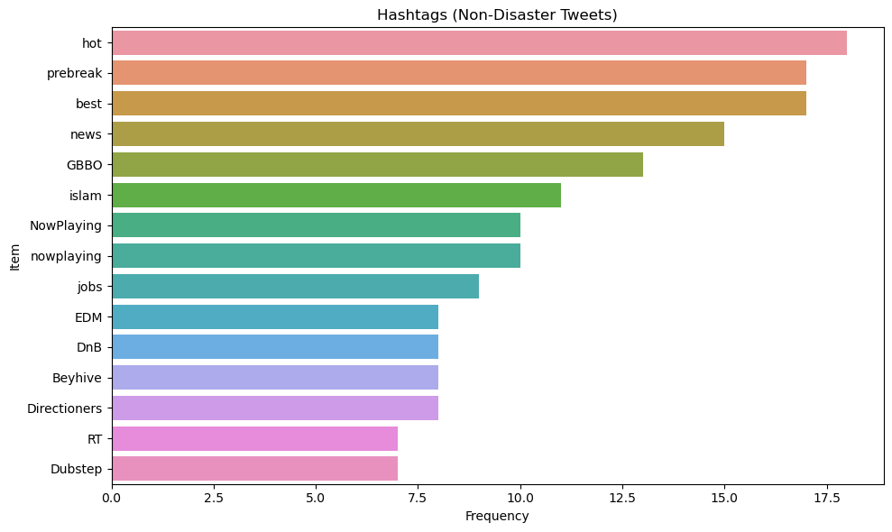

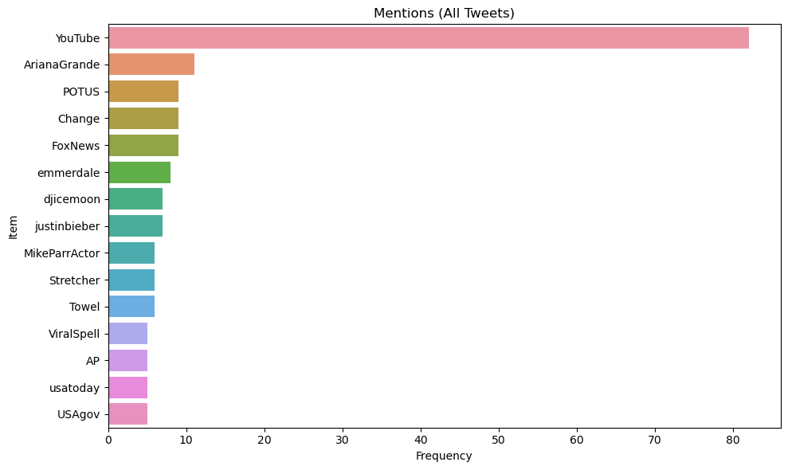

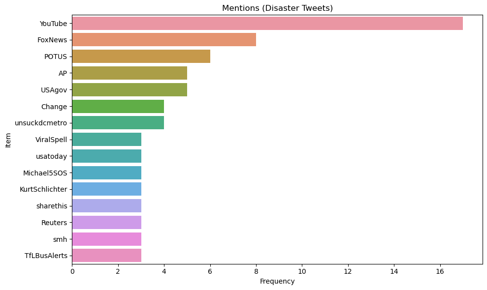

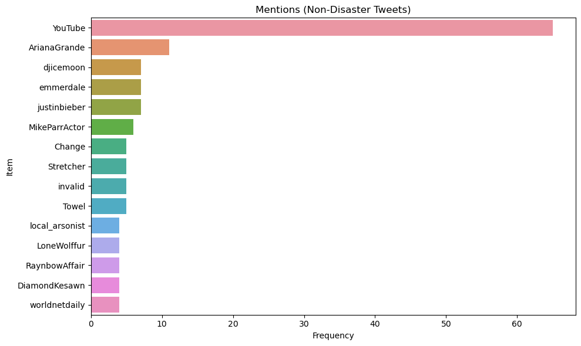

```python
# Extract hashtags and mentions
def extract_hashtags(text):
    return re.findall(r"#(\w+)", text)

def extract_mentions(text):
    return re.findall(r"@(\w+)", text)

df['hashtags'] = df['text'].apply(extract_hashtags)
df['mentions'] = df['text'].apply(extract_mentions)

# Flatten helper
def flatten_lists(series):
    return sum(series, [])

# Count top N
def get_top_counts(items, top_n=15):
    return pd.DataFrame(Counter(items).most_common(top_n), columns=['item', 'count'])

# Visualize
def plot_top_items(df_items, title):
    plt.figure(figsize=(10,6))
    sns.barplot(data=df_items, y='item', x='count')
    plt.title(title)
    plt.xlabel("Frequency")
    plt.ylabel("Item")
    plt.tight_layout()
    plt.show()


# Getting the Top Hashtags
hashtags_all = flatten_lists(df['hashtags'])
hashtags_dis = flatten_lists(df[df.target==1]['hashtags'])
hashtags_non = flatten_lists(df[df.target==0]['hashtags'])

plot_top_items(get_top_counts(hashtags_all), "Hashtags (All Tweets)")
plot_top_items(get_top_counts(hashtags_dis), "Hashtags (Disaster Tweets)")
plot_top_items(get_top_counts(hashtags_non), "Hashtags (Non-Disaster Tweets)")

# Getting the top Mentions
mentions_all = flatten_lists(df['mentions'])
mentions_dis = flatten_lists(df[df.target==1]['mentions'])
mentions_non = flatten_lists(df[df.target==0]['mentions'])

plot_top_items(get_top_counts(mentions_all), "Mentions (All Tweets)")
plot_top_items(get_top_counts(mentions_dis), "Mentions (Disaster Tweets)")
plot_top_items(get_top_counts(mentions_non), "Mentions (Non-Disaster Tweets)")
```

For the hashtags, we can see an overabundance of the words News and news in the disaster tweets. This makes sense because you would expect the word news to be used to describe something happening that is fairly important. News organizations such as FoxNews, AP, usatoday, reuters are on the disaster list which reflects reporting events. Keeping in mind though that news can be used in different ways you can see that news is also on the non-disaster tweet list.

Mentions are more clearly defined within the disaster categories. The top disaster mentions are YouTube, FoxNews, and POTUS which would clearly indicate major evenst occurring. The non-disaster tweets are mentioning YouTube as well, but notice that things like ArianaGrande and justinbieber are on that list. So, ultimately I think the mentions are reflecting a clear definition between the diaster and non-disaster tweets.